# TestingEvidence

Requirement ID

Requirement description:

Test Class:

Pass/Fail

Evidence

UR01

The game must be programmed in Java

Manual - from GitHub showing the languages used for the project

Pass

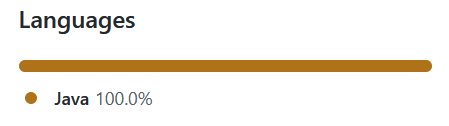

UR02

A racing game that is won by the boat with the fastest time

TestScreensGameFlow.java

Pass

See JUnit test report

UR03

To have the player compete against 3-6 AI opponents

Manual

Pass

See TestEvidence Number (2,3,5)

UR04

Each boat should have a different set of balanced attributes

TestBoatStats.java

Pass

See JUnit test report

UR05

If the player leaves their lane then a time penalty will be incurred

TestOutsideLane.java

Pass

See JUnit test report

UR06

Hitting obstacles will result in a decrease of robustness and disappearing of the obstacle

TestObstacles.java

Pass

See JUnit test report

UR07

If the players health decreases to 0, they will lose

TestObstacle.java

Pass

See JUnit test report

UR08

Player gets tired over time, therefore the speed, acceleration and maneuverability will decrease

Pass

See JUnit test report

UR 09

The controls should be keyboard and mouse

Pass

See JUnit test report

UR10

There should be good graphics, animation, audio to make the game interesting

Manual

Pass

See TestEvidence Number (All)

UR11

Show time of each leg

Manual

Pass

See TestEvidence Number (2,3)

UR12

Recovering of energy when it’s not used

Pass

See JUnit test report

UR13

Implement different levels of difficulty in the game

TestDifficulty.java

Pass

See JUnit test report

UR14

Create a save, load function

Manual

Pass

See TestEvidence Number (1)

UR15

Implement five power-up packs which improve attributes

TestPowerups.java

Pass

See JUnit test report

UR16

Implement a demo mode.

Manual

Pass

See TestEvidence Number (2)

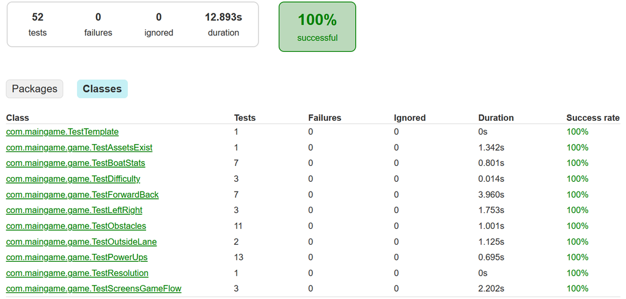

1. (Manual) Saving and Loading the game

Evidence:

No JUnit testing evidence, but manual testing evidence confirms that this is functioning:

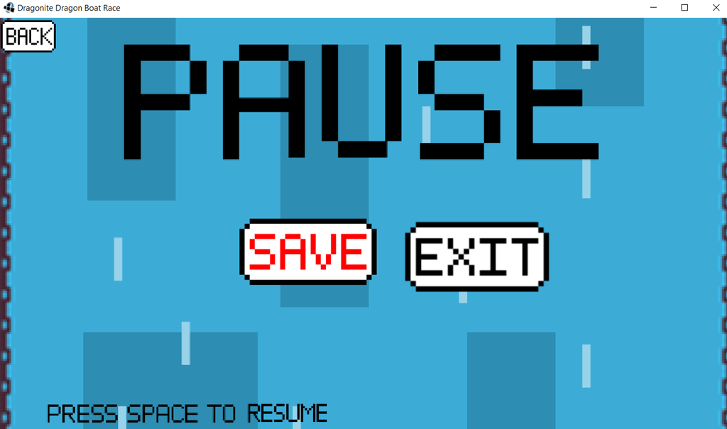

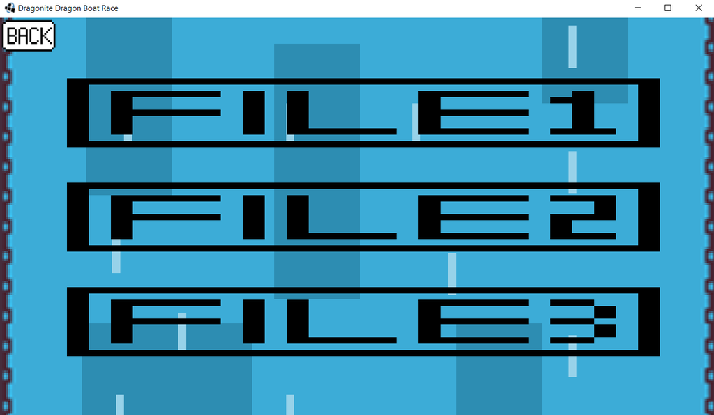

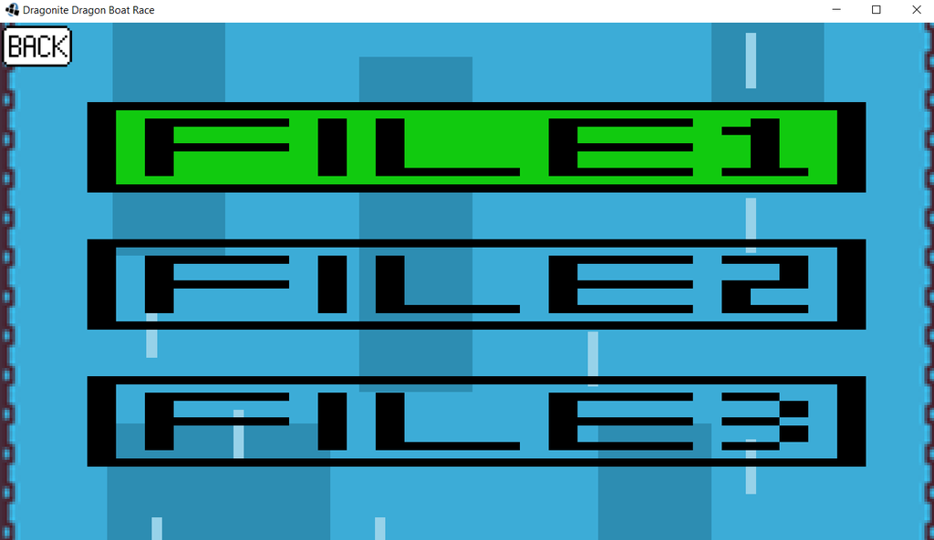

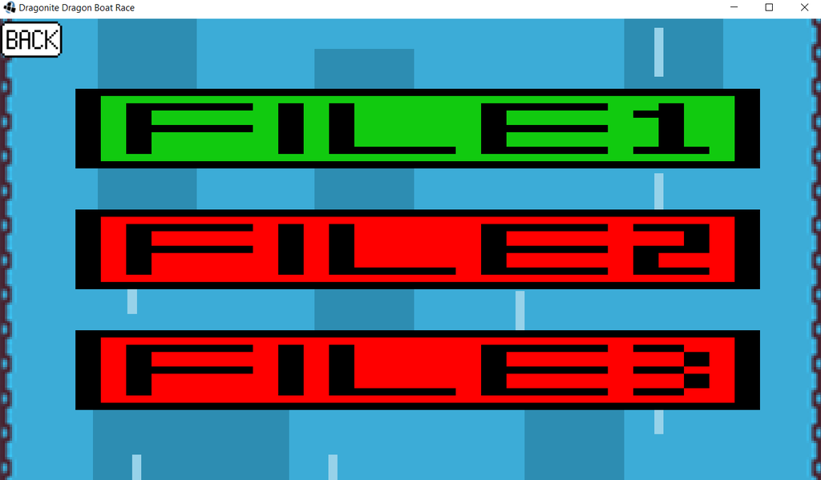

2. (Manual) Demo mode has been implemented

Evidence:

No JUnit testing evidence, but manual testing evidence confirms that this is functioning:

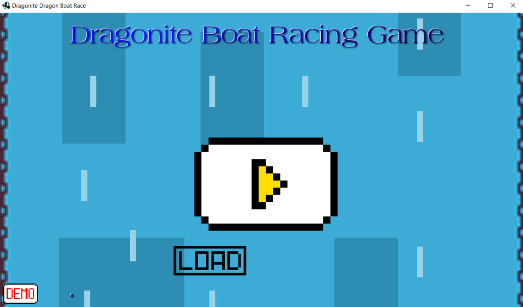

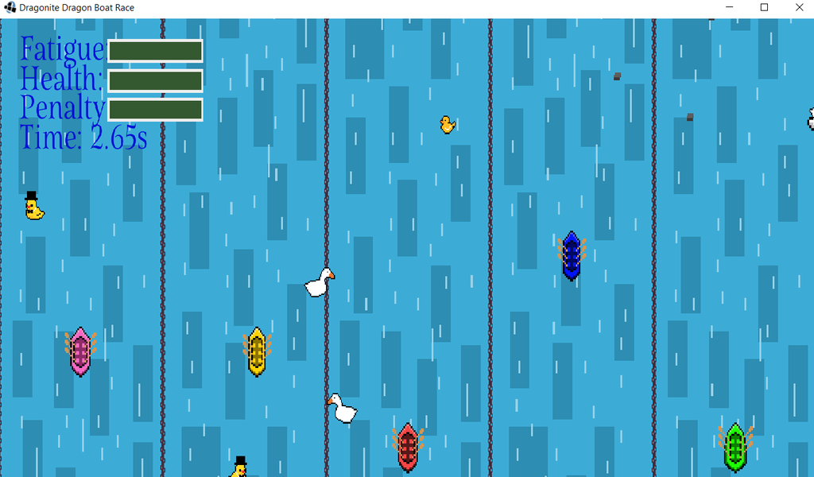

3. (Manual) finish line reached game stop (all)

Evidence:

No JUnit testing evidence, but manual testing evidence confirms that this is functioning:

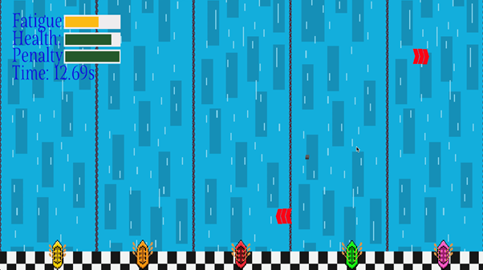

4. (Manual) Game over screen if not in top 3 in leg 3

No JUnit testing evidence, but manual testing evidence confirms that this is functioning:

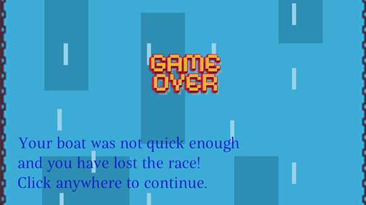

5. (Manual) penalty time increase if outbound(True)

No JUnit testing evidence, but manual testing evidence confirms that this is functioning:

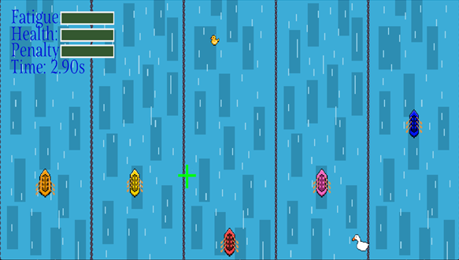

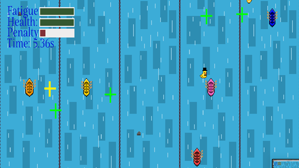

The running and functioning of the game manually, as evidenced in previous tests, evidence by implication that game start True is working.

6. (Manual) boat chosen true

7. (Manual) switching boat true

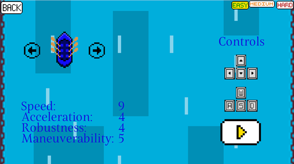

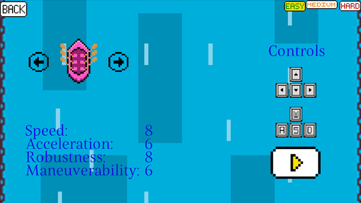